# GLMMs: worked examples

### Diagnostics

The standard diagnostic plot for the `glmer` fits is a little better than in the binary case, but not much:

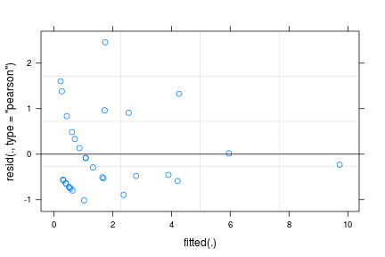

```r
plot(gmod_lme4_L)
```

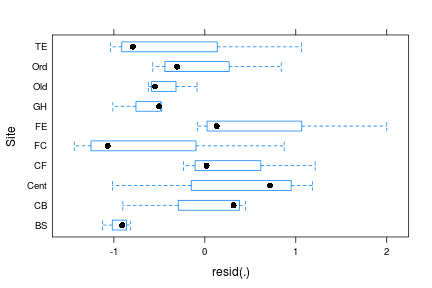

```r
plot(gmod_lme4_L,Site~resid(.))
```

However, it turns out that those boxplots are really only representing three values per site (i.e., site \( \times \) year combinations): we can see this if we use `ggplot` to overlay points on the boxplots. While we're at it, we might as well reorder the `Site` factor to be in order of mean residuals. (**WARNING**: if you have loaded the `scapeMCMC` package to get prettier MCMC diagnostic plots such as `plotTrace`, you have also incidentally loaded the `reorder.factor` function from the `gdata` package, which changes the default behaviour of the `reorder` function, and there is a subtle bug in it as well. You need to make sure to specify `FUN=mean` *and* `sort=sort` explicitly to make it work …)

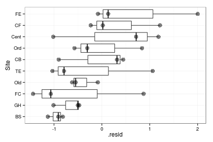

```r
ff <- fortify(gmod_lme4_L)
ff <- transform(ff,Site=reorder(Site,X=.resid,FUN=mean,sort=sort))
ggplot(ff,aes(x=Site,y=.resid))+geom_boxplot()+
    geom_point(size=4,alpha=0.5)+
    coord_flip()
```

There seems to be a fair amount of among-site variation, but apparently (at least according to `glmer`) this amount of among-site variation is still consistent with Poisson variation among otherwise identical sites …

We have already checked for overdispersion, above, and found the residuals to be under- rather than overdispersed.

We can do *posterior predictive simulations* to test whether the model is behaving like the data in other ways. For example, looking at the distributions of the numbers of zero-shell outcomes in simulated data:

```r
sims <- simulate(gmod_lme4_L,nsim=1000)
nzeros <- colSums(sims==0)
par(las=1,bty="l")
plot(pt <- prop.table(table(nzeros)),
     ylab="Probability")
(obszero <- sum(Gdat$shells==0))
```

```
## [1] 9
```

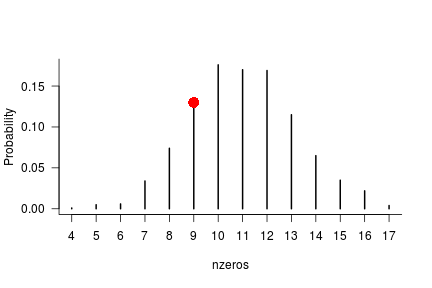

```r
points(obszero,0.13,col="red",pch=16,cex=2)
```

A two-sided \( p \)-value, if we felt one were necessary:

```r
sum(pt[names(pt) %in% c(4:9,13:18)])
```

```
## [1] 0.485
```

We conclude that the model is doing a good job matching this characteristic of the data (i.e., we can't reject the null hypothesis that it's doing a good job …)

We can easily do this for other characteristics of the data that we were interested in, such as among-site variance. In this case we will use the `glm()` fit to simulate and re-fit, since it's much faster than `glmer()` and suitable for this task:

```r
sims2 <- simulate(gmod_glm,nsim=1000)
vfun <- function(x) {
    m_new <- update(gmod_glm,data=transform(Gdat,shells=x))
    Gdat$.resid <- residuals(m_new,"pearson")
    sitemeans <- ddply(Gdat,"Site",summarise,mresid=mean(.resid))
    var(sitemeans$mresid)
}
vdist <- sapply(sims2,vfun)
```

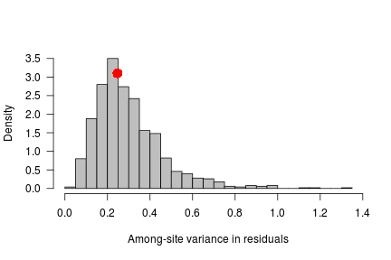

```r
Gdat$.glmresid <- residuals(gmod_glm,"pearson")
obs_sitemeans <- ddply(Gdat,"Site",summarise,mresid=mean(.glmresid))
obs_sitevar <- var(obs_sitemeans$mresid)
par(las=1,bty="l")
hist(vdist,breaks=30,col="gray",freq=FALSE,main="",
     xlab="Among-site variance in residuals")
par(xpd=NA) ## prevent point getting cut off at top of plot
points(obs_sitevar,3.1,col="red",pch=16,cex=2)
```

The observed among-site variance is almost exactly what we would expect from Poisson variation with no true site-to-site variation.

#### MCMCglmm

We write a small utility function to automate the process of combining the fixed-effect (`Sol`) and variance-covariance (`VCV`) parameter chains and making the trace plot:

```r
tfun <- function(mod) {
    plotTrace(as.mcmc(cbind(mod$Sol,mod$VCV)))
}
```

As suggested above, the default results are again bad.

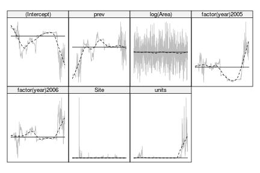

```r
tfun(gmod_MG0)
```

Running for longer doesn't help that much:

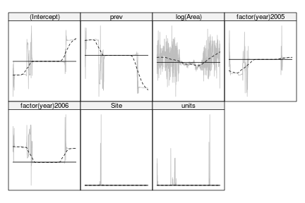

```r
tfun(gmod_MG)
```

Looks OK with the improved priors, though:

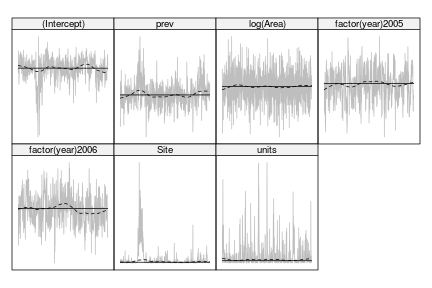

```r
tfun(gmod_MG2)
```

We can again look at the variance parameters on the log scale to decide that they're not *too* bad:

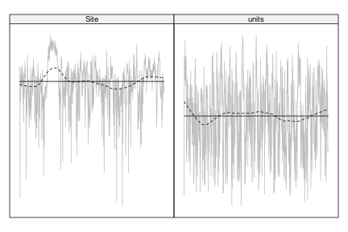

```r
vcChain <- log10(gmod_MG2$VCV)
plotTrace(vcChain)
```

### Inference

Computing confidence intervals and comparing estimates and CIs across the range of estimation and inference approaches:

```r
gmod_CIwald <- confint(gmod_lme4_L,method="Wald")
gmod_CIprof <- confint(gmod_lme4_L,quiet=TRUE)
gmod_CIboot <- confint(gmod_lme4_L,method="boot",quiet=TRUE)
```

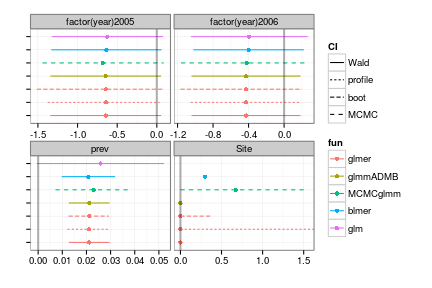

I've plotted each of the parameters in a separate facet because their scales are somewhat different (it might also be worth scaling `prev` by its standard deviation in order to make comparisons, as suggested by Schielzeth 2010, but the `Site` variable would still differ somewhat).

### Prediction

What if we want to re-plot our original data with predictions about the effect of seroprevalence overlaid?

```r
g_pframe <- cbind(expand.grid(year=2004:2006,prev=0:80),Area=1)
g_pred <- predict(gmod_lme4_L,newdata=g_pframe,re.form=NA,
                  type="response")
```

```r
g_predCI <- easyPredCI(gmod_lme4_L,newdata=g_pframe)
```

```r
set.seed(101)
g_bb <- bootMer(gmod_lme4_L,
              FUN=function(x)
              predict(x,re.form=NA,newdata=g_pframe,
              type="response"),
              nsim=400)
```

```r
gpredboot1.CI <- t(sapply(1:nrow(g_pframe),
       function(i)
         boot.ci(g_bb,type="perc",index=i)$percent[4:5]))
## or: t(apply(bb$t,2,quantile,c(0.025,0.975),na.rm=TRUE))
```

```r
g_pframe2 <- cbind(g_pframe,shells=g_pred,g_predCI,
              setNames(as.data.frame(gpredboot1.CI),
                       c("lwr_boot","upr_boot")))
gplot_pred1 <- gplot1 +
  geom_line(data=g_pframe2,aes(colour=factor(year)))+
         geom_ribbon(data=g_pframe2,
                     aes(group=factor(year),
                         ymin=1+lwr,ymax=1+upr),
                     alpha=0.1)
gplot_pred2 <- gplot1 +
  geom_line(data=g_pframe2,aes(colour=factor(year)))+
         geom_ribbon(data=g_pframe2,
                     aes(group=factor(year),
                         ymin=1+lwr_boot,ymax=1+upr_boot),
                     alpha=0.1)
```

The confidence intervals from the parametric bootstrap (right-hand plot) are quite similar:

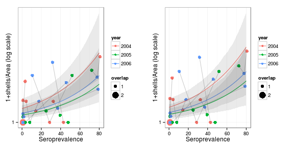

```r
grid.arrange(gplot_pred1,gplot_pred2,nrow=1)
```

## Grouse ticks

These data are those used in Elston *et al.*, “Analysis of aggregation, a worked example: numbers of ticks on red grouse chicks”“ *Parasitology*, 122(5):563-569, 2001 (kindly donated by Robert Moss *via* David Elston).

```r
tickdata = read.table("Elston2001_tickdata.txt",header=TRUE,
colClasses=c("factor","numeric","factor","numeric","factor","factor"))
```

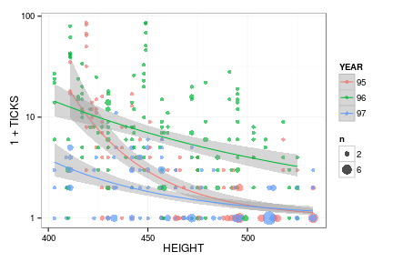

```r
ggplot(tickdata,aes(x=HEIGHT,y=1+TICKS,colour=YEAR))+
    stat_sum(aes(size=..n..),alpha=0.7)+
    scale_y_log10()+
    scale_size_continuous(breaks=c(2,6,10),range=c(2,7))+
    geom_smooth(method="glm",family=quasipoisson)
```

The quasi-Poisson GLM fits shown here ignore the grouping structure, but are useful for structuring the data (although the `HEIGHT` effect is of secondary interest here – we're mostly interested in the relative variances at the individual, brood, and location levels).

Center the height data (as recommended by Gelman and Hill 2006, Schielzeth 2010) otherwise we will have trouble with both optimization- and MCMC-based approaches.

```r
tickdata <- transform(tickdata,cHEIGHT=HEIGHT-mean(HEIGHT))
```

Because `INDEX`, `BROOD`, and `LOCATION` are uniquely labeled, we can specify the random effect as *either* `(1|LOCATION)+(1|BROOD)+(1|INDEX)` or `(1|LOCATION/BROOD/INDEX)`, although the latter might be clearer:

```r
tmod_lme4_L <- glmer(TICKS~YEAR+cHEIGHT+(1|LOCATION/BROOD/INDEX),
                    family="poisson",data=tickdata,
                    control=glmerControl(optimizer="bobyqa",
                           check.conv.grad=.makeCC("warning",2e-3)))
```

(I switched the optimizer used and increased the convergence-checking tolerance slightly here: hopefully this will be unnecessary in future versions of `lme4`.)

```r
print(summary(tmod_lme4_L),corr=FALSE)
```

```
## Generalized linear mixed model fit by maximum likelihood (Laplace
##   Approximation) [glmerMod]
##  Family: poisson  ( log )
## Formula: TICKS ~ YEAR + cHEIGHT + (1 | LOCATION/BROOD/INDEX)
##    Data: tickdata
## Control:
## glmerControl(optimizer = "bobyqa", check.conv.grad = .makeCC("warning",
##     0.002))
##
##      AIC      BIC   logLik deviance df.resid
##   1794.5   1822.5   -890.3   1780.5      396
##
## Scaled residuals:
##    Min     1Q Median     3Q    Max
## -1.612 -0.554 -0.149  0.285  2.443
##
## Random effects:
##  Groups                 Name        Variance Std.Dev.
##  INDEX:(BROOD:LOCATION) (Intercept) 0.293    0.542
##  BROOD:LOCATION         (Intercept) 0.563    0.750
##  LOCATION               (Intercept) 0.280    0.529
## Number of obs: 403, groups:  INDEX:(BROOD:LOCATION), 403
## BROOD:LOCATION, 118 LOCATION, 63
##
## Fixed effects:
##             Estimate Std. Error z value Pr(>|z|)
## (Intercept)  0.37279    0.19637    1.90   0.0576 .
## YEAR96       1.18040    0.23812    4.96  7.2e-07 ***
## YEAR97      -0.97869    0.26278   -3.72   0.0002 ***
## cHEIGHT     -0.02376    0.00344   -6.91  4.8e-12 ***
## ---
## Signif. codes:  0 '***' 0.001 '**' 0.01 '*' 0.05 '.' 0.1 ' ' 1
```

This all looks reasonable; centering the height has given us a sensible intercept (otherwise it would correspond, ridiculously, to the expected number of ticks per grouse at sea level), the other parameters are sensible, and the variance is approximately equally divided between random-effects levels (when we work with variance decomposition it makes sense to interpret the random effects on the variance rather than the standard deviation scale).

```r
tmod_gA_L <- glmmadmb(TICKS~YEAR+cHEIGHT+(1|LOCATION/BROOD/INDEX),
                      family="poisson",data=tickdata)
```

Since `MCMCglmm` automatically adds an observation-level random effect, we specify only `BROOD` and `LOCATION`, leaving out `INDEX`:

```r
tmod_MG <- MCMCglmm(TICKS~cHEIGHT+YEAR,
                 random=~BROOD+LOCATION,
                 family="poisson",data=tickdata,
                 verbose=FALSE)
```

Once again we will need to try this with an informative prior. I initially specified `(nu=5,V=1)` for both the `BROOD` and `LOCATION` levels, but Hadfield suggests expanded parameters instead:

```r
prior.t <- list(R=list(nu=0.002,V=1),
                G=list(G1=list(V=1, nu=1, alpha.mu=0, alpha.V=1000),
                G2=list(V=1, nu=1, alpha.mu=0, alpha.V=1000)))
```

```r
tmod_MG2 <- MCMCglmm(TICKS~cHEIGHT+YEAR,
                     random=~BROOD+LOCATION,
                     prior=prior.t,
                     family="poisson",data=tickdata,
                     verbose=FALSE)
```

Comparing results (just the random effects):

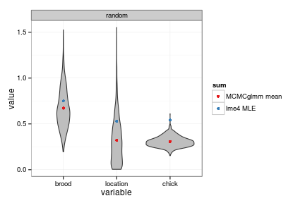

For comparison, and because Elston et al. originally used penalized quasi-likelihood to fit their models, we use `MASS::glmmPQL` to fit the model. We don't include `INDEX` in this model either, because `glmmPQL` also includes a residual error term by default.

```r
tmod_PQL <- glmmPQL(TICKS~cHEIGHT+YEAR,
                    random=~1|LOCATION/BROOD,
                    family="poisson",data=tickdata,
                    verbose=FALSE)
```

### Diagnostics

The diagnostic plot is clearer if we plot the fitted values on the log scale:

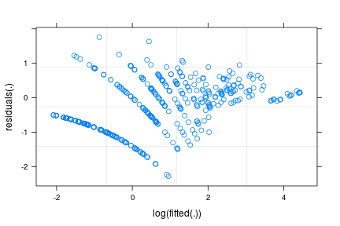

```r
plot(tmod_lme4_L,residuals(.) ~log(fitted(.)))
```

`ggplot(fortify(.))` puts the fitted values on the log scale by default. Here is a scale-location plot, which shows some tendency of the variance of the residuals to decrease with the mean:

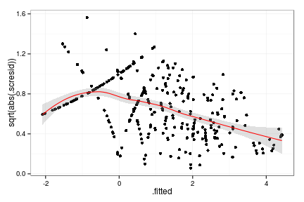

```r
ggplot(fortify(tmod_lme4_L),
       aes(x=.fitted,y=sqrt(abs(.scresid))))+geom_point()+
    geom_smooth(colour="red",alpha=0.3)
```

We can look at the residuals grouped by location:

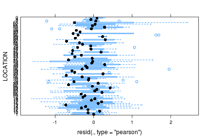

```r
plot(tmod_lme4_L,LOCATION~resid(.,type="pearson"))
```

`ggplot` makes it a little bit easier to re-order the locations by mean residual:

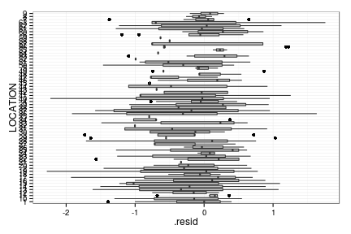

```r
ff <- fortify(tmod_lme4_L)
ff <- transform(ff,LOCATION=reorder(LOCATION,.resid,fun=MEAN,sort=sort))
ggplot(ff, aes(x=LOCATION,y=.resid))+geom_boxplot(fill="gray")+coord_flip()
```

We can also look at the conditional modes:

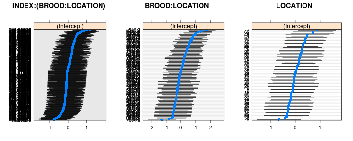

```r
dd <- dotplot(ranef(tmod_lme4_L,condVar=TRUE))
do.call(grid.arrange,c(dd,list(nrow=1)))
```

As we have come to expect, the trace plots for the default `MCMCglmm` run are a bit problematic:

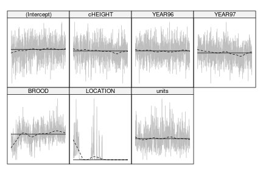

```r
tfun(tmod_MG)
```

The adjusted run is a bit better:

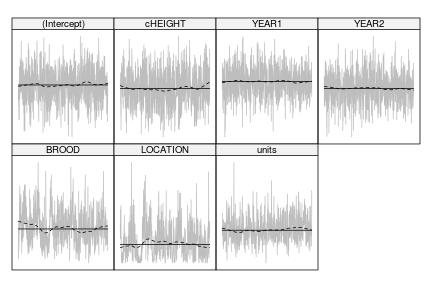

```r
tfun(tmod_MG2)
```

We can also look at the pairwise distributions, which look OK (we focus on the variance parameters here):

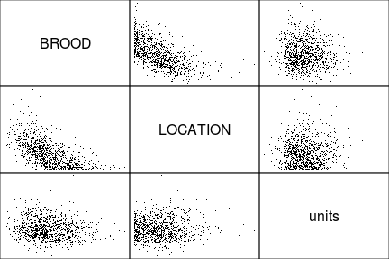

```r
plotSplom(tmod_MG2$VCV,pch=".")
```

(using `pch="."` can be effective when you are looking at large samples).

Or we can look at the density plots

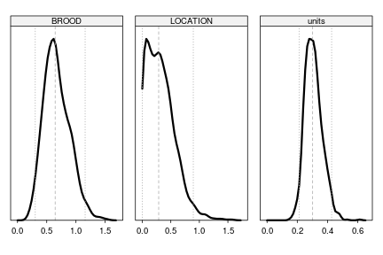

```r
plotDens(tmod_MG2$VCV,from=0,layout=c(3,1),asp="fill",las=1)
```

```r
pp <- profile(tmod_lme4_L)
tmod_lme4_ciprof <- confint(pp)
```

```r
tmod_lme4_ciboot <- confint(tmod_lme4_L,method="boot",
                            nsim=500,quiet=TRUE,seed=101)
```

[figure not shown]

```r
all_Results <- rbind(data.frame(example="ticks",tmod_Results),
                     data.frame(example="gopher",gmod_Results),
                     data.frame(example="culcita",cmod_Results))
save("all_Results",file="all_Results.RData")
```

Using the results from `MCMCglmm` we can compute the posterior probability (for example) that the among-brood variance is greater than the among-chick variance:

```r
with(as.data.frame(tmod_MG2$VCV),
     mean(BROOD>units))
```

```
## [1] 0.969
```

We can also compute the distribution of the ratio of among-brood to among-chick variance …

```r
with(as.data.frame(tmod_MG2$VCV),
     summary(BROOD/units))
```

```
##    Min. 1st Qu.  Median    Mean 3rd Qu.    Max.
##   0.529   1.630   2.150   2.270   2.780   5.780
```

… or the 95% quantiles …

```r
with(as.data.frame(tmod_MG2$VCV),
     quantile(BROOD/units,c(0.025,0.975)))
```

```
##   2.5%  97.5%
## 0.9458 4.4290
```

… or the highest posterior density intervals …

```r
HPDinterval(mcmc(with(as.data.frame(tmod_MG2$VCV),BROOD/units)))
```

```
##       lower upper
## var1 0.9184 4.266
## attr(,"Probability")
## [1] 0.95
```